# Guides - Legends

2017-07-06

# Introduction

This is the 13th post in the series **Elegant Data Visualization with ggplot2**. In the previos [post](https://rsquaredacademy.github.io/blog/post/guides-axes/), we learnt how to modify the axis of plots. In this post, we will focus on modifying the legends of plots when the aesthetics are mapped to variables.

- `scale_*()` family of functions
- `guides()`
- `guide_legend()` and `guide_colorbar()`

Let us start with `scale_*()` family of functions.

- `scale_alpha_continuous()`

If you have mapped alpha to a continuous variable, use `scale_alpha_continuous()` to modify it. Let us create a simple scatter plot and map alpha to a continuous variable.

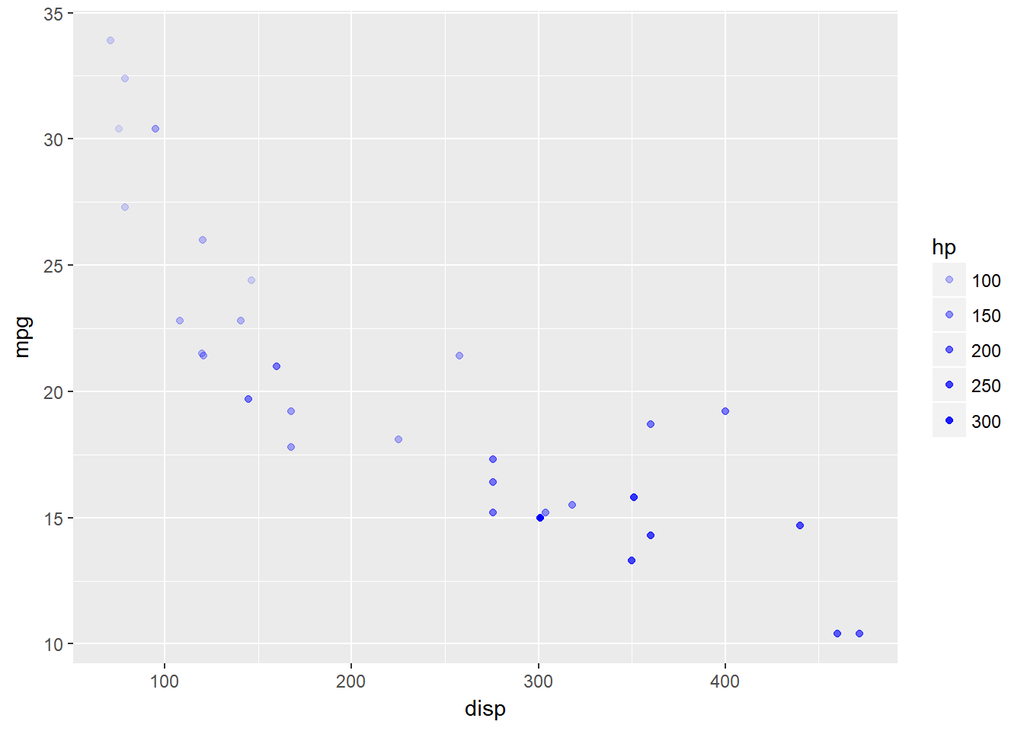

```r
ggplot(mtcars) +
  geom_point(aes(disp, mpg, alpha = hp), color = 'blue')
```

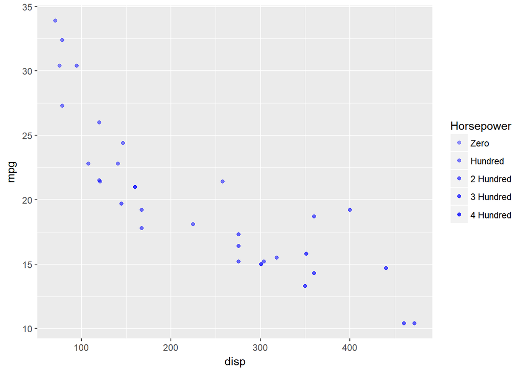

```r
ggplot(mtcars) +
  geom_point(aes(disp, mpg, alpha = hp), color = 'blue') +
  scale_alpha_continuous("Horsepower",
                         breaks = c(0, 100, 200, 300, 400),
                         limits = c(0, 400),
                         labels = c("Zero", "Hundred", "2 Hundred",
                                    "3 Hundred", "4 Hundred"),
                         range = c(0.4, 0.8))
```

- `scale_alpha_discrete()`:

If you have mapped alpha to a discrete variable, use `scale_alpha_discrete()` to modify it. Let us create a simple scatter plot and map alpha to a discrete variable.

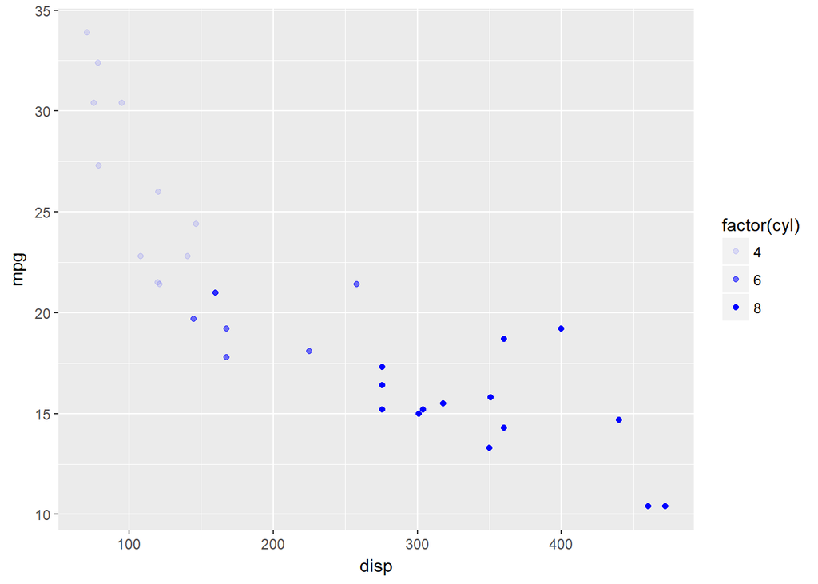

```r
ggplot(mtcars) +
  geom_point(aes(disp, mpg, alpha = factor(cyl)), color = 'blue')
```

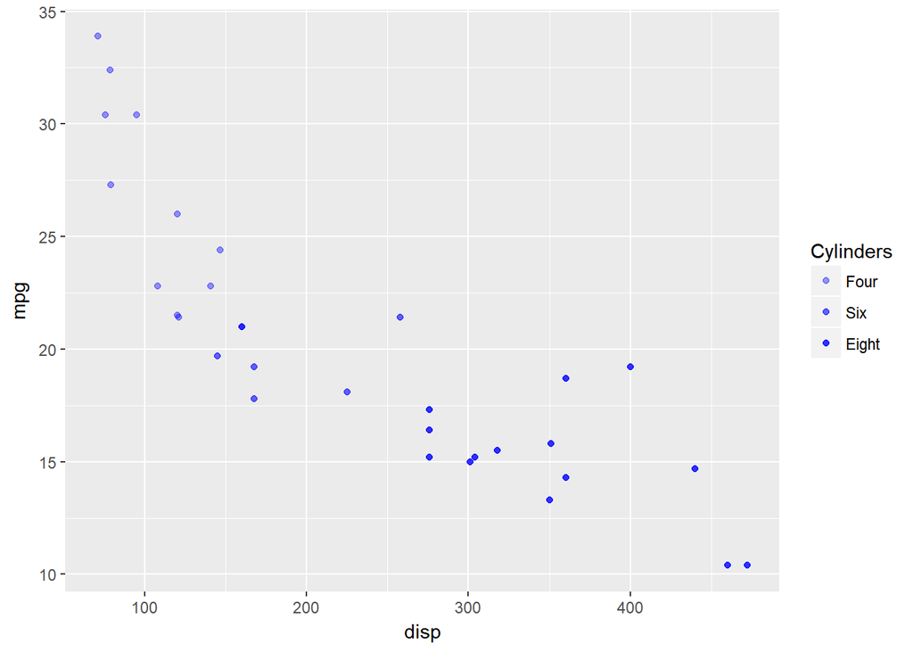

```r
ggplot(mtcars) +
  geom_point(aes(disp, mpg, alpha = factor(cyl)), color = 'blue') +
  scale_alpha_discrete(name = "Cylinders",
                       breaks = c("4", "6", "8"),
                       labels = c("Four", "Six", "Eight"),
                       range = c(0.4, 0.8))
```

- `scale_color_manual()`:

If you have mapped color to a discrete variable, use `scale_color_manual()` to modify it. Let us create a simple scatter plot and map color to a discrete variable.

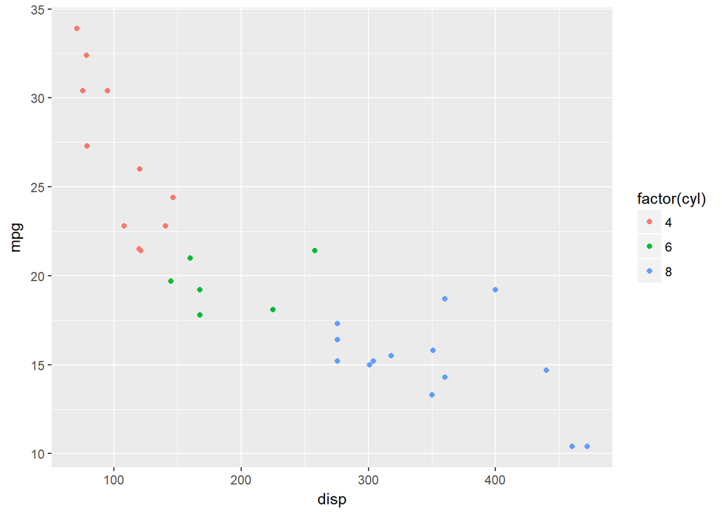

```r
ggplot(mtcars) +
  geom_point(aes(disp, mpg, color = factor(cyl)))
```

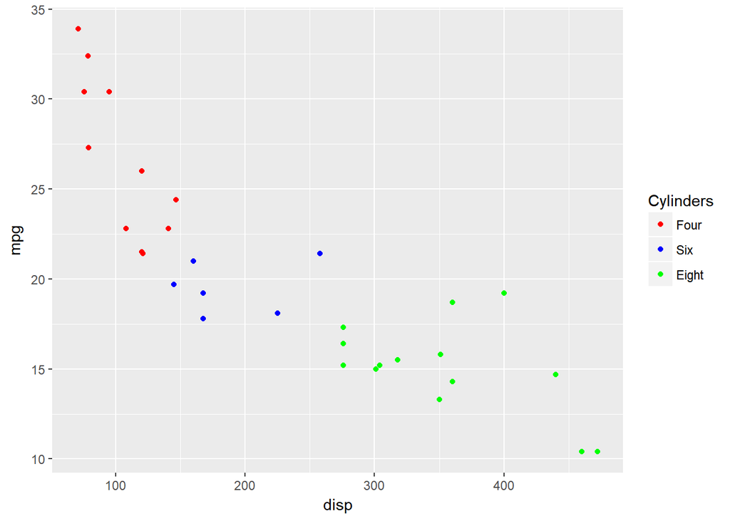

```r
ggplot(mtcars) +
  geom_point(aes(disp, mpg, color = factor(cyl))) +
  scale_color_manual(name = "Cylinders",
                     values = c("red", "blue", "green"),
                     labels = c('Four', 'Six', 'Eight'),
                     limits = c(4, 6, 8),
                     breaks = c(4, 6, 8),
                     guide = "legend")
```

- `scale_fill_manual()`:

If you have mapped fill to a discrete variable, use `scale_fill_manual()` to modify it. Let us create a simple scatter plot and map fill to a discrete variable.

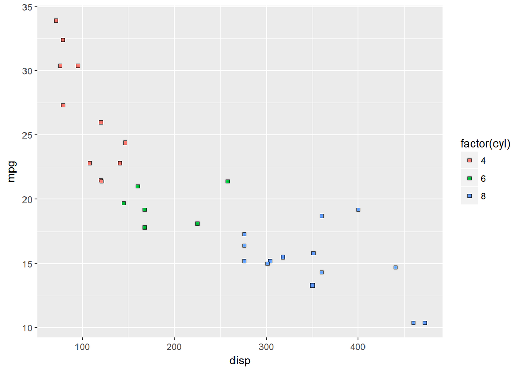

```r
ggplot(mtcars) +
  geom_point(aes(disp, mpg, fill = factor(cyl)), shape = 22)
```

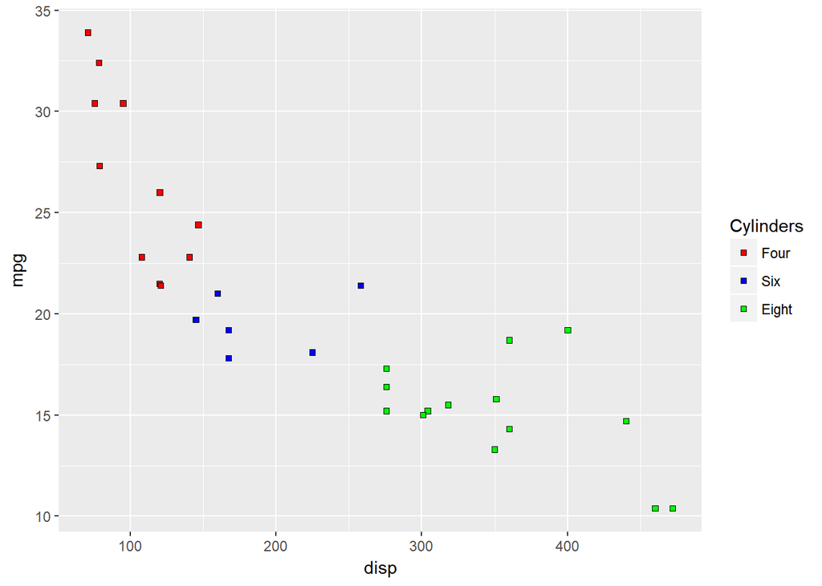

```r
ggplot(mtcars) +
  geom_point(aes(disp, mpg, fill = factor(cyl)), shape = 22) +
  scale_fill_manual(name = "Cylinders",
                     values = c("red", "blue", "green"),
                     labels = c('Four', 'Six', 'Eight'),
                     limits = c(4, 6, 8),
                     breaks = c(4, 6, 8),
                     guide = "legend")
```

- `scale_shape_manual()`

If you have mapped shape to a discrete variable, use `scale_shape_manual()` to modify it. Let us create a simple scatter plot and map shape to a discrete variable.

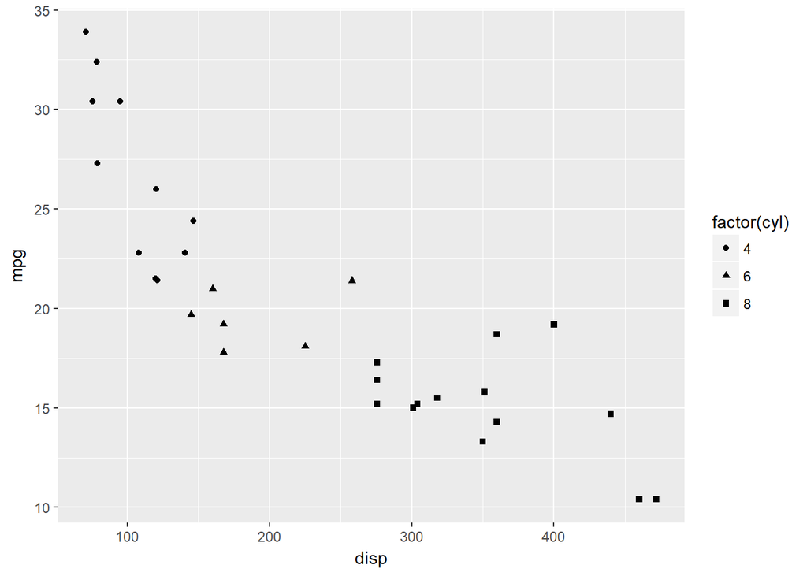

```r
ggplot(mtcars) +
  geom_point(aes(disp, mpg, shape = factor(cyl)))
```

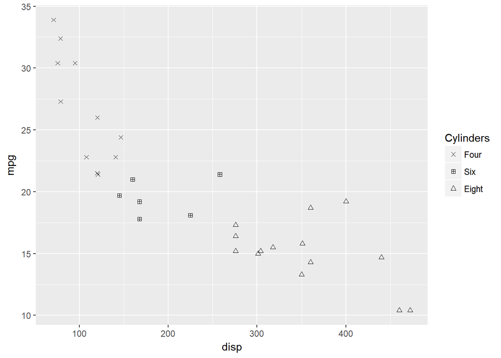

```r
ggplot(mtcars) +
  geom_point(aes(disp, mpg, shape = factor(cyl))) +
  scale_shape_manual(name = "Cylinders",
                    values = c(4, 12, 24),
                    labels = c('Four', 'Six', 'Eight'),
                    limits = c(4, 6, 8),
                    breaks = c(4, 6, 8),
                    guide = "legend")
```

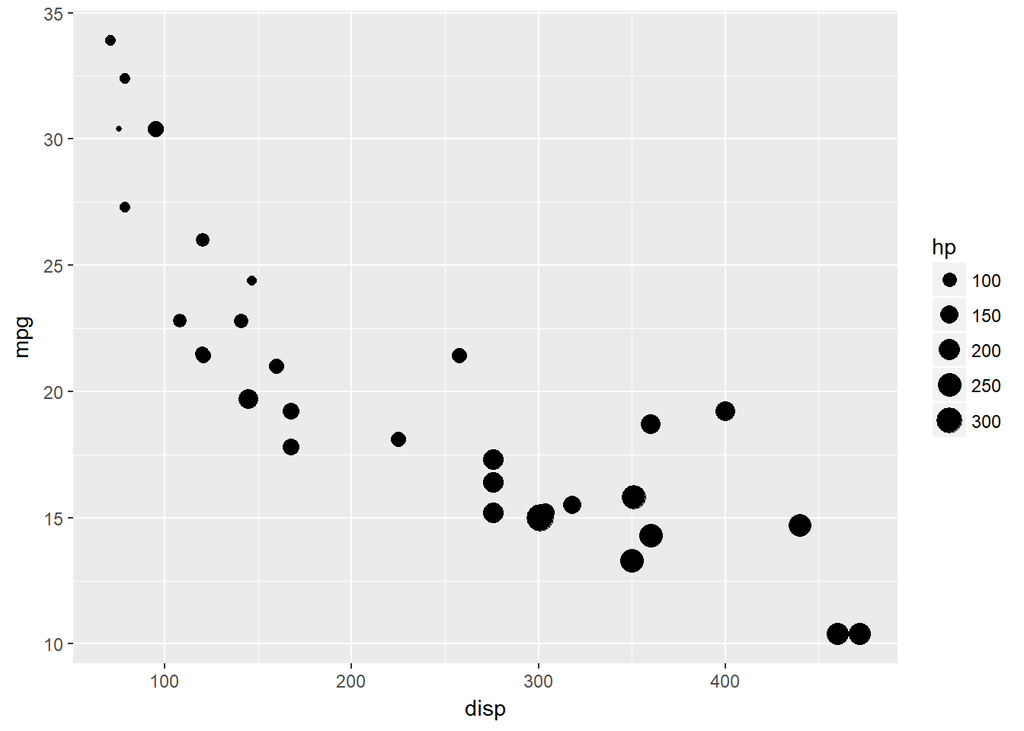

```r
ggplot(mtcars) +
  geom_point(aes(disp, mpg, size = hp))
```

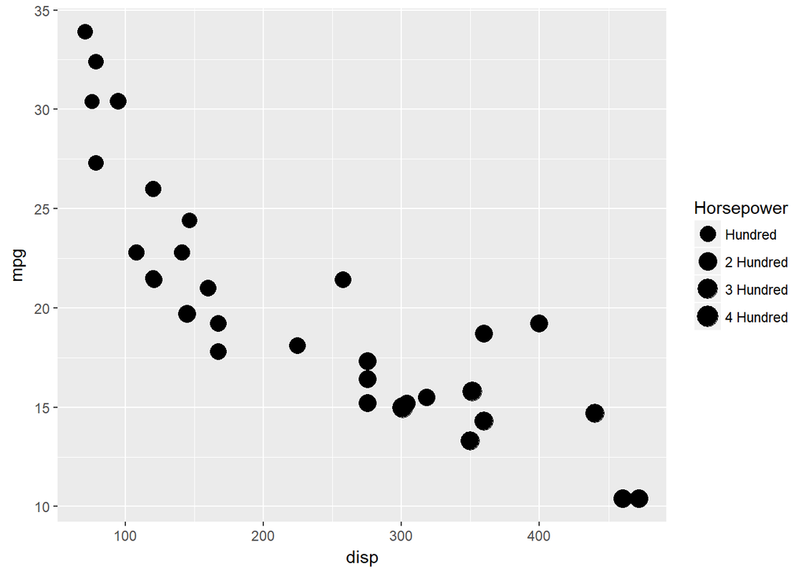

```r
ggplot(mtcars) +
  geom_point(aes(disp, mpg, size = hp)) +
  scale_size_continuous(name = "Horsepower",
                        range = c(3, 6),
                        limits = c(0, 400),
                        breaks = c(100, 200, 300, 400),
                        labels = c("Hundred", "2 Hundred",
                                   "3 Hundred", "4 Hundred"))
```

- `scale_alpha_manual()`

If you have mapped alpha to a discrete variable, use `scale_alpha_manual()` to modify it. Let us create a simple scatter plot and map alpha to a discrete variable.

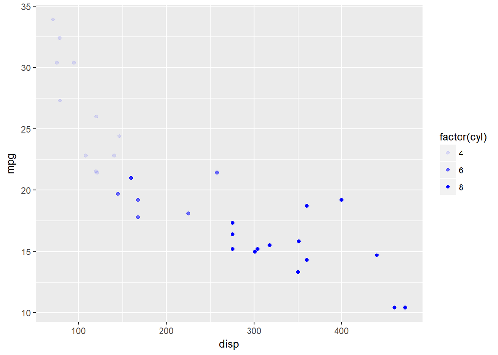

```r
ggplot(mtcars) +
  geom_point(aes(disp, mpg, alpha = factor(cyl)), color = 'blue')
```

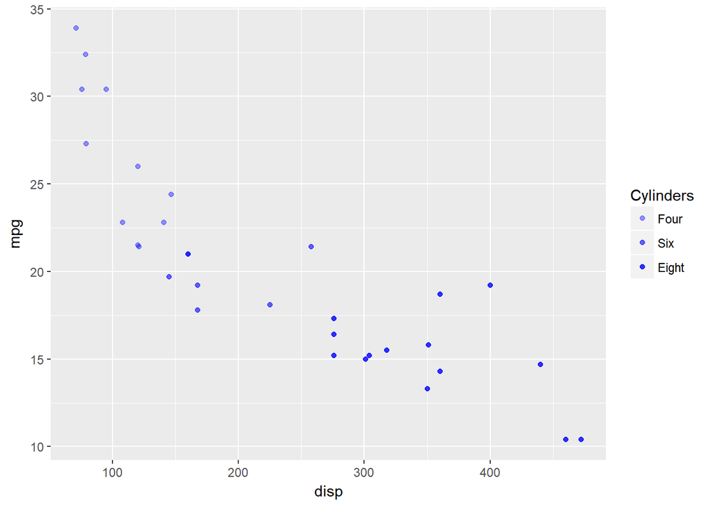

```r
ggplot(mtcars) +
  geom_point(aes(disp, mpg, alpha = factor(cyl)), color = 'blue') +
  scale_alpha_manual(name = "Cylinders",
                     values = c(0.4, 0.6, 0.8),
                     labels = c('Four', 'Six', 'Eight'),
                     limits = c(4, 6, 8),
                     breaks = c(4, 6, 8),
                     guide = "legend")
```

- `scale_shape()`: maps discrete variable to six shapes

If you have mapped shape to a discrete variable, use `scale_shape()` to modify it. Let us create a simple scatter plot and map shape to a discrete variable.

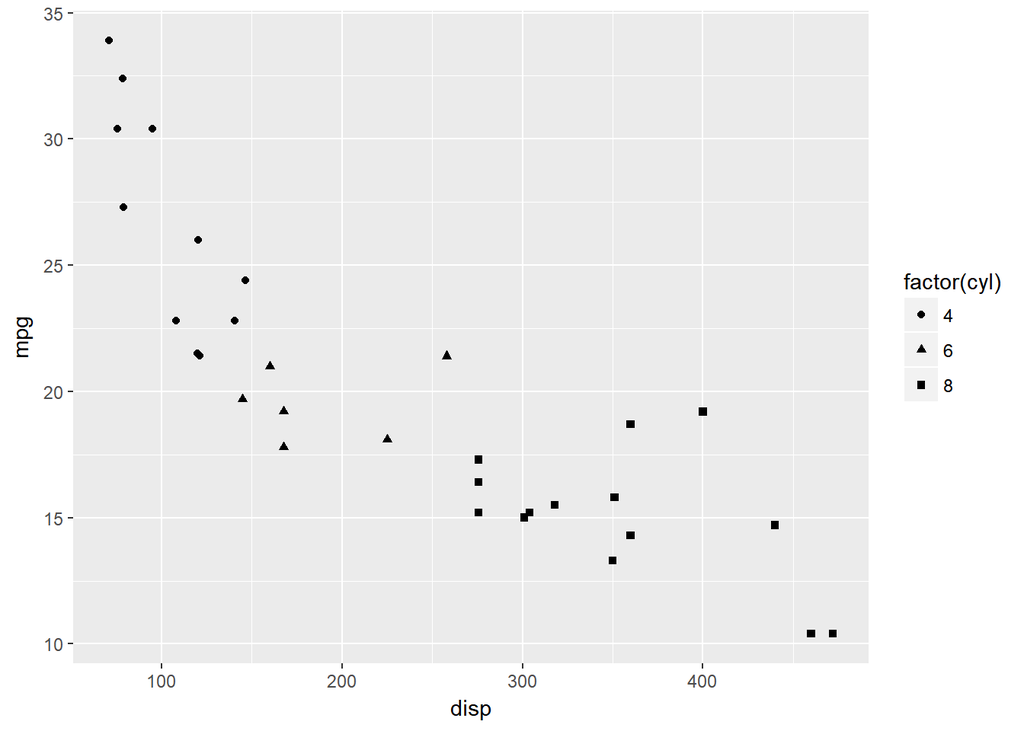

```r
ggplot(mtcars) +
  geom_point(aes(disp, mpg, shape = factor(cyl))) +
  scale_shape()
```

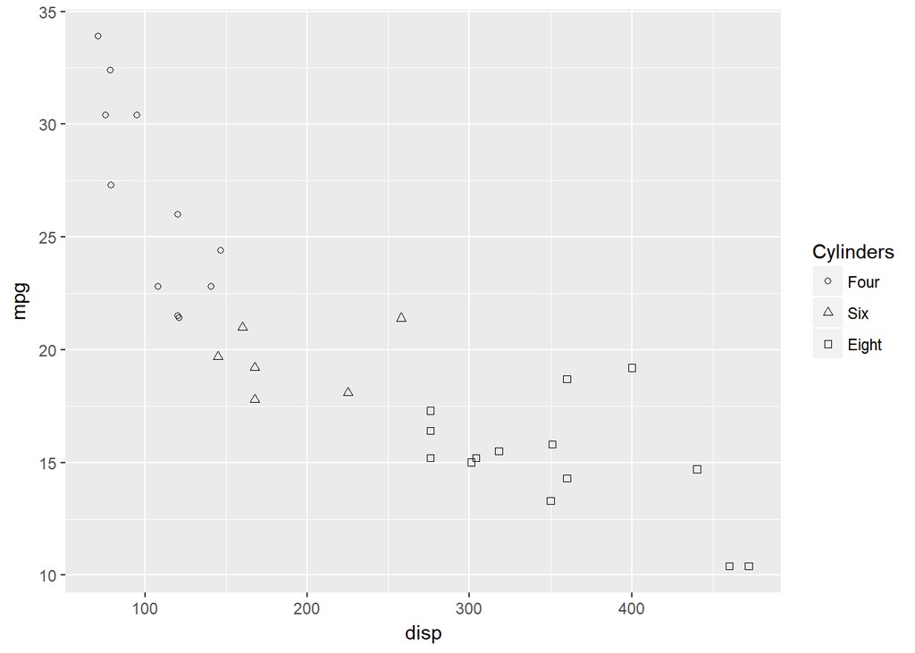

```r
ggplot(mtcars) +
  geom_point(aes(disp, mpg, shape = factor(cyl))) +
  scale_shape(solid = FALSE,
              name = 'Cylinders',
              labels = c('Four', 'Six', 'Eight'),
              limits = c(4, 6, 8),
              breaks = c(4, 6, 8))
```

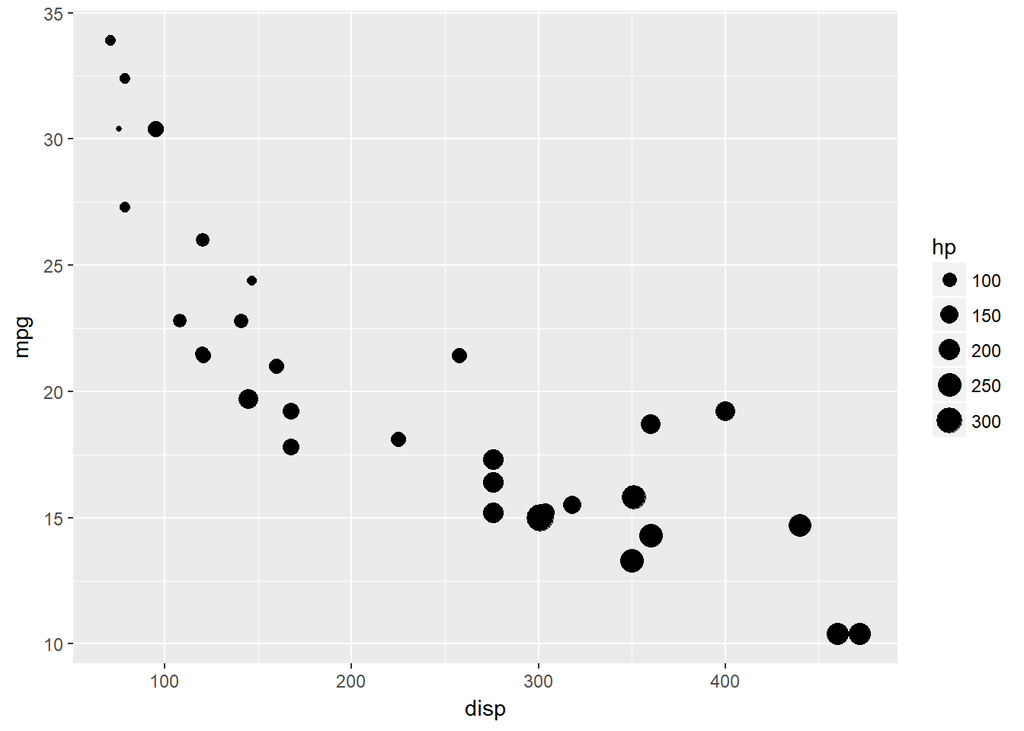

```r
ggplot(mtcars) +
  geom_point(aes(disp, mpg, size = hp))
```

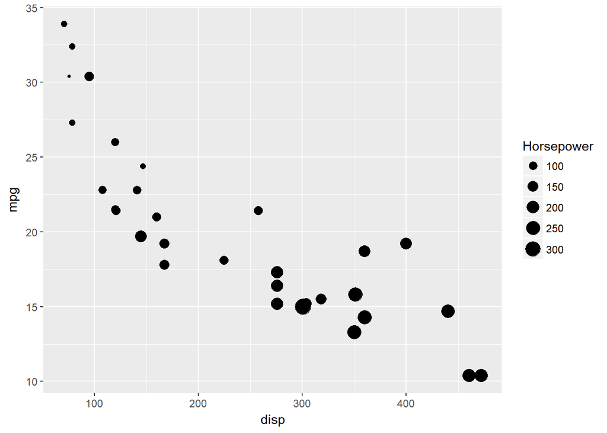

```r
ggplot(mtcars) +
  geom_point(aes(disp, mpg, size = hp)) +
  scale_size(name = "Horsepower")
```

## Guides

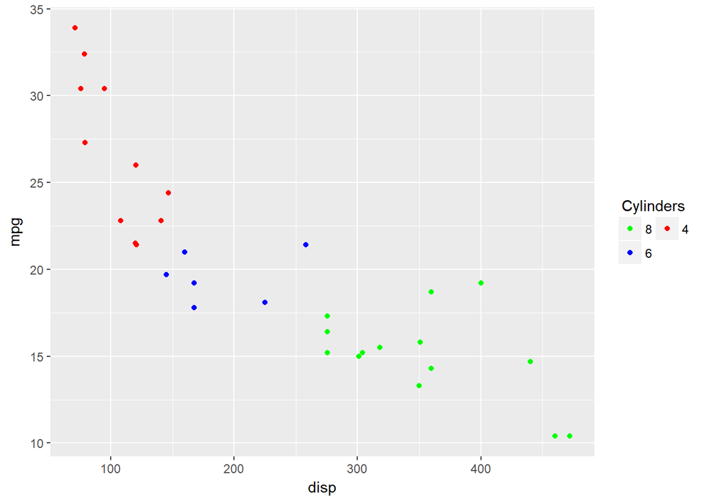

```r
ggplot(mtcars) +
  geom_point(aes(disp, mpg, color = factor(cyl))) +
  scale_color_manual(values = c("red", "blue", "green"),
                      guide = guide_legend(
                       title = "Cylinders",
                       title.hjust = 0.5,
                       title.position = "top",
                       label.position = "right",
                       direction = "horizontal",
                       label.hjust = 0.5,
                       nrow = 2,
                       reverse = TRUE
                      )
  )
```

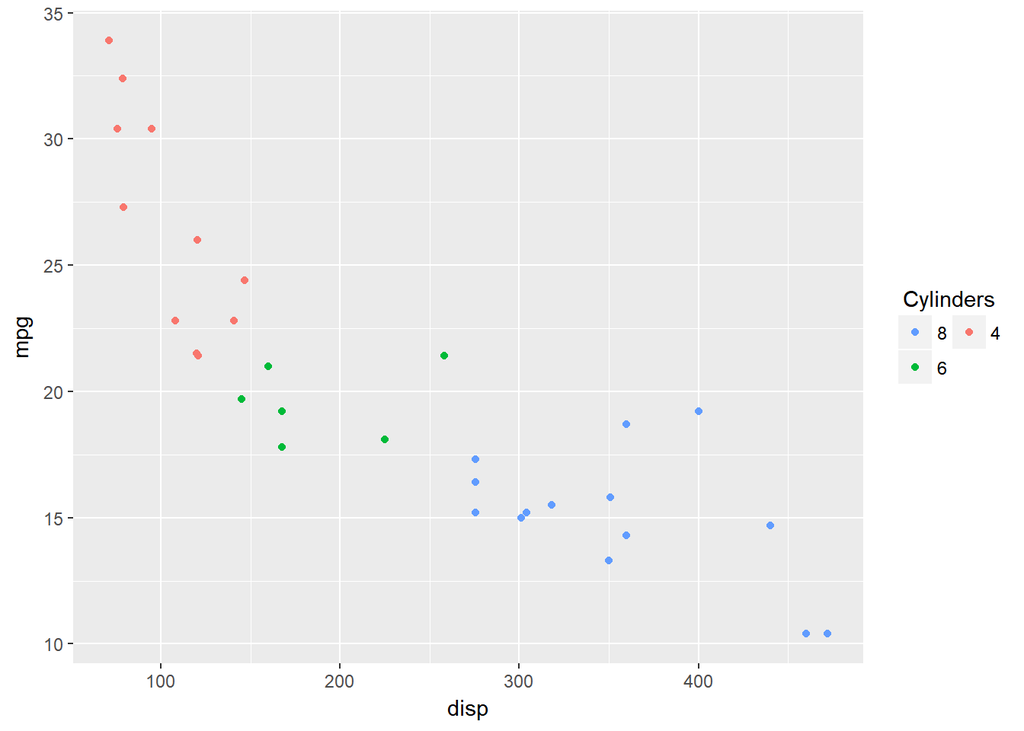

```r
ggplot(mtcars) +
  geom_point(aes(disp, mpg, color = factor(cyl))) +
  scale_color_discrete(guide = guide_legend(
                        title = "Cylinders",
                        title.hjust = 0.5,
                        title.position = "top",
                        label.position = "right",
                        direction = "horizontal",
                        label.hjust = 0.5,
                        nrow = 2,
                        reverse = TRUE
                        )
  )
```

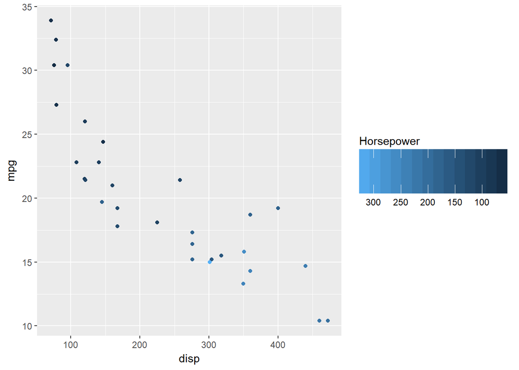

```r
ggplot(mtcars) +
  geom_point(aes(disp, mpg, color = hp)) +
  scale_color_continuous(guide = guide_colorbar(
    title = "Horsepower",
    title.position = "top",
    title.vjust = 1,
    label.position = "bottom",
    label.vjust = 0.8,
    barwidth = 10,
    barheight = 3,
    nbins = 10,
    raster = FALSE,
    ticks = TRUE,
    draw.ulim = TRUE,
    draw.llim = FALSE,
    direction = "horizontal",
    reverse = TRUE
  ))
```

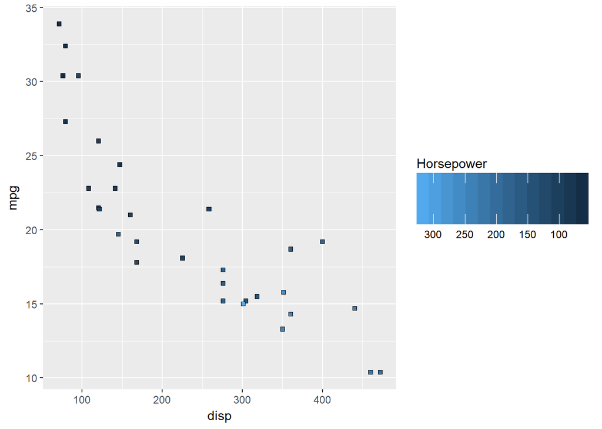

```r
ggplot(mtcars) +
  geom_point(aes(disp, mpg, fill = hp), shape = 22) +
  scale_fill_continuous(guide = guide_colorbar(
    title = "Horsepower",
    title.position = "top",
    title.vjust = 1,
    label.position = "bottom",
    label.vjust = 0.8,
    barwidth = 10,
    barheight = 3,
    nbins = 10,
    raster = FALSE,
    ticks = TRUE,
    draw.ulim = TRUE,
    draw.llim = FALSE,
    direction = "horizontal",
    reverse = TRUE)
  )
```

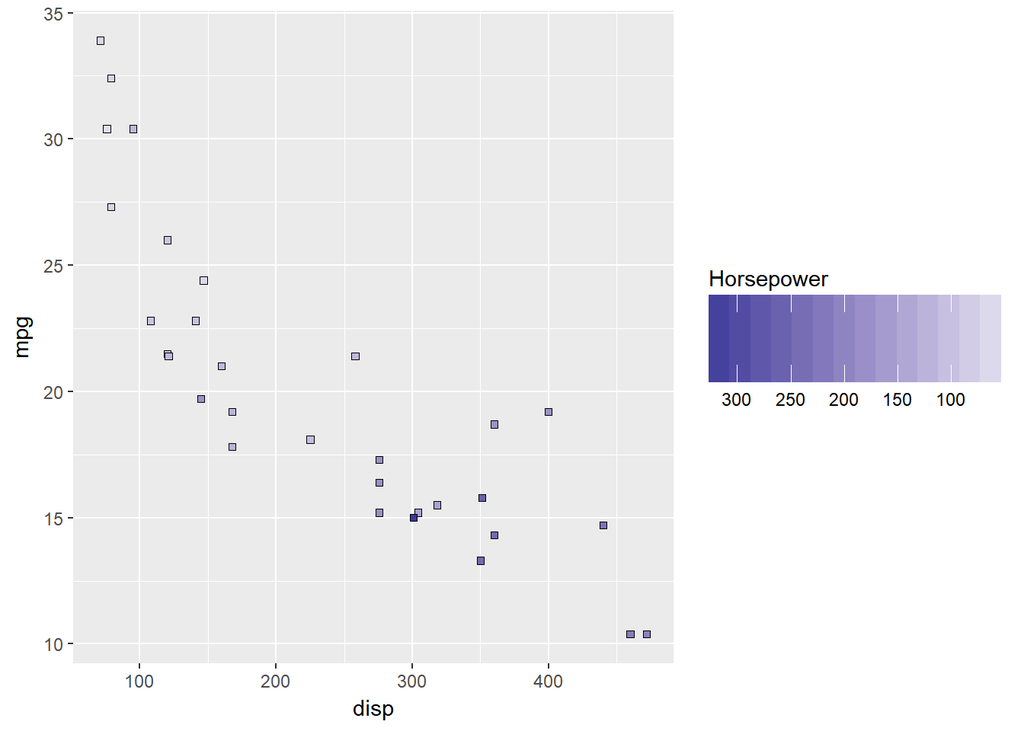

```r
ggplot(mtcars) +
  geom_point(aes(disp, mpg, fill = hp), shape = 22) +
  scale_fill_gradient2(guide = guide_colorbar(
    title = "Horsepower",
    title.position = "top",
    title.vjust = 1,
    label.position = "bottom",
    label.vjust = 0.8,
    barwidth = 10,
    barheight = 3,
    nbins = 10,
    raster = FALSE,
    ticks = TRUE,
    draw.ulim = TRUE,
    draw.llim = FALSE,
    direction = "horizontal",
    reverse = TRUE)
  )
```

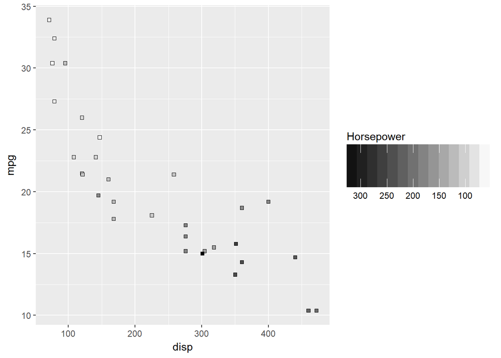

```r
ggplot(mtcars) +
  geom_point(aes(disp, mpg, fill = hp), shape = 22) +
  scale_fill_gradient(low = "white", high = "black",
    guide = guide_colorbar(
      title = "Horsepower",
      title.position = "top",
      title.vjust = 1,
      label.position = "bottom",
      label.vjust = 0.8,
      barwidth = 10,
      barheight = 3,
      nbins = 10,
      raster = FALSE,
      ticks = TRUE,
      draw.ulim = TRUE,
      draw.llim = FALSE,
      direction = "horizontal",
      reverse = TRUE
    )
  )
```

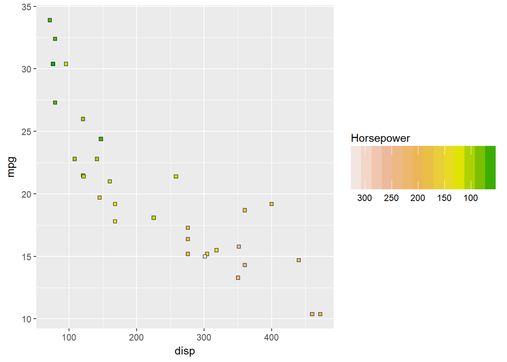

```r
ggplot(mtcars) +
  geom_point(aes(disp, mpg, fill = hp), shape = 22) +
  scale_fill_gradientn(colors = terrain.colors(5),
    guide = guide_colorbar(
      title = "Horsepower",
      title.position = "top",
      title.vjust = 1,
      label.position = "bottom",
      label.vjust = 0.8,
      barwidth = 10,
      barheight = 3,
      nbins = 10,
      raster = FALSE,
      ticks = TRUE,
      draw.ulim = TRUE,
      draw.llim = FALSE,
      direction = "horizontal",
      reverse = TRUE
    )
  )
```

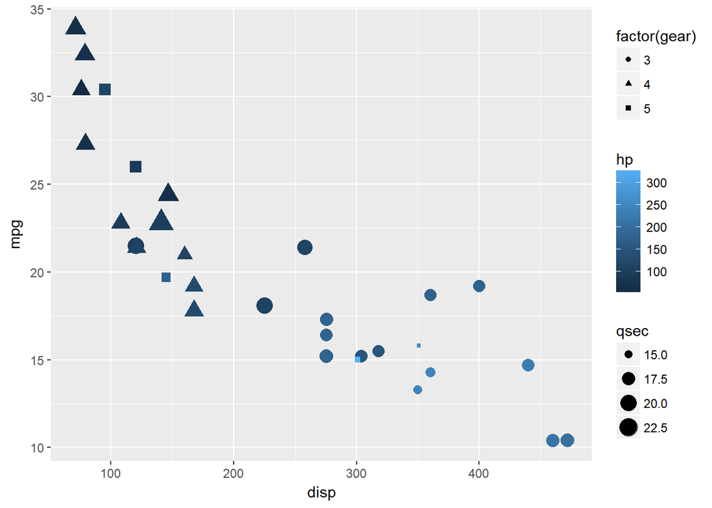

```r
ggplot(mtcars) +
  geom_point(aes(disp, mpg, color = hp,
                 size = qsec,
                 shape = factor(gear))) +
  guides(color = "colorbar",
         shape = "legend",
         size = "legend")
```

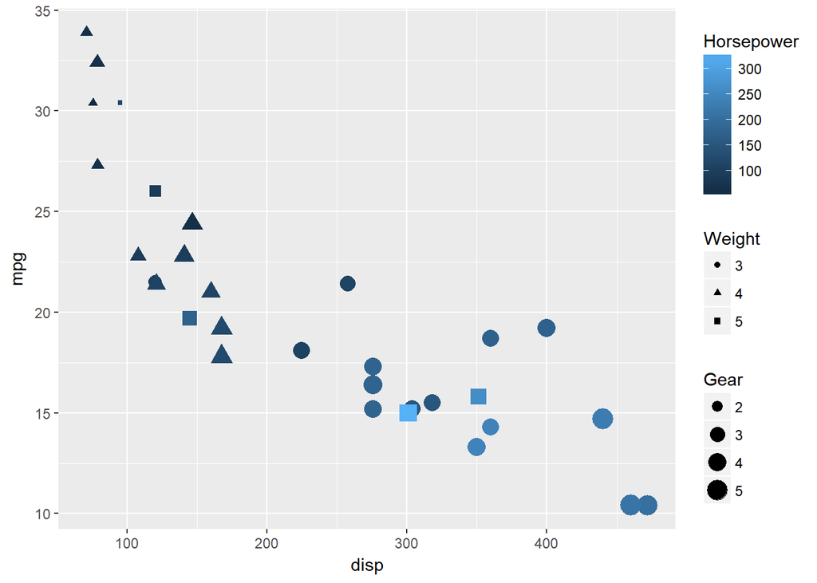

```r
ggplot(mtcars) +
  geom_point(aes(disp, mpg, color = hp,
                 size = wt,
                 shape = factor(gear))) +
  guides(
    color = guide_colorbar(
      title = "Horsepower"
    ),
    shape = guide_legend(
      title = "Weight"
    ),
    size = guide_legend(
      title = "Gear"
    )
  )
```